# Effect of Radiation and Diet on Aortic damage

Sonia De Leo

20Feb2024

# 1 **Description of the Dataset and Experiment**

## 1.1 **Source of the Data & Credits**

The following dataset was obtained from ‘Análisis de la Varianza: Carrera de Especialización en Estadísticas para Ciencias de la Salud (CEECS). Universidad de Buenos Aires. Instituto de Cálculo’.

## 1.2 **Objectives**

Ionizing radiation used with therapeutic objectives produces secondary effects in the vascular system. It is suspected that radiation damage effects can be also potenciated by hypercholesterolemia.

The objective of the experiment is to study the effects of radiation and high cholesterol diets on endothelial damage.

## 1.3 **Experimental Design and Statistical Approach**

40 mice were exposed to radiation (0 Gy, 4 Gy, 8 Gy and 12 Gy), and standard or high-fat diets. Mice were divided in 8 groups of equal size and each group was assigned a combination of radiation intensity and diet. Mice were sacrificed and aortic lesion was assessed from two histological samples and lesion area was measured in µm^2. More information about this type of experiments can be found in Trible, et al. 1.

In the present analysis, Mixed model ANOVA is used to obtain statistical conclusions about the effect of Radiation and Diet on aortic Area. Multiple comparisons of the different treatment groups and visualizations of results are showed.

## 1.4 **Dataset**

|  | Id | Mouse | Radiation | Diet | Area |
| --- | --- | --- | --- | --- | --- |
| 1 | 1 | 1 | 0 | standard | 0.48 |
| 2 | 2 | 2 | 0 | standard | 2.10 |
| 3 | 3 | 3 | 0 | standard | 0.47 |
| 4 | 4 | 4 | 0 | standard | 1.05 |
| 5 | 5 | 5 | 0 | standard | 1.67 |
| 6 | 6 | 6 | 0 | high-fat | 3.37 |

### 1.4.2 **Variables:**

There are 5 variables in the dataset:

```
## [1] "Id"        "Mouse"     "Radiation" "Diet"      "Area"
```

### 1.4.3 **Variable Description**

- **Area**: Aortic lesioned area measured from cardiac histological samples used as an indicator of vascular damage. A higher area is indicative of higher damage. Units: µm^2. Type of variable: Continuous numeric variable.
- **Diet**: Diet treatment. High-fat or standard diet administered to mice. Type of variable: Categorical variable. Levels: standard and high-fat.
- **Radiation**: Ionizing radiation applied to mice. Type of vaiable: Categorical variable (ordinal). Levels: 0, 4, 8, 12. Units: Gy.
- **Mouse**: Mouse identifier. Levels: 1 to 40.
- **Id**: Id identifies each histological sample obtained. Two samples (and two area measurements) were obtained for each mice. Levels: 1 to 80.

### 1.4.4 **Variable Summary:**

|  | Id | Mouse | Radiation | Diet | Area |
| --- | --- | --- | --- | --- | --- |
| Type of variable | factor | factor | factor | factor | numeric |
| Data type | integer | integer | integer | integer | double |
| Levels-Range | 1to80 | 1to40 | 0, 4, 8, 12 | standard, high-fat | 0.365-11.7 |

**Table 2:** Summary of type of variables, type of data and levels (categorical variables) or range (numeric variable).

### 1.4.5 **Data Summary**

```
##        Id         Mouse    Radiation       Diet         Area
##  1      : 1   1      : 2   0 :20     standard:40   Min.   : 0.365
##  2      : 1   2      : 2   4 :20     high-fat:40   1st Qu.: 1.998
##  3      : 1   3      : 2   8 :20                   Median : 3.410
##  4      : 1   4      : 2   12:20                   Mean   : 4.256
##  5      : 1   5      : 2                           3rd Qu.: 5.402
##  6      : 1   6      : 2                           Max.   :11.700
##  (Other):74   (Other):68
```

**Table 3:** Summary of variables.

# 2 **Exploratory Data Analysis (EDA)**

## 2.1 **Graphical Analysis**

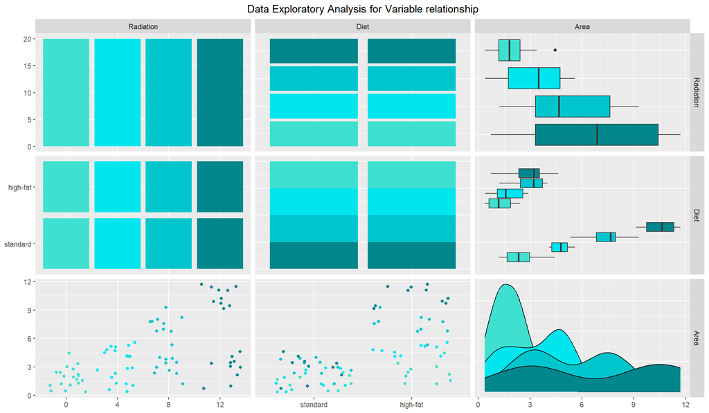

**Figure 1:** Exploratory Data Analysis between pairs of treatments. Radiation levels are represented with different shades of turquoise. Variables distribution is showed in the diagonal line. Radiation levels: 0, 4, 8 and 12 Gy. Diet levels: ‘standard’ and ‘high-fat’.

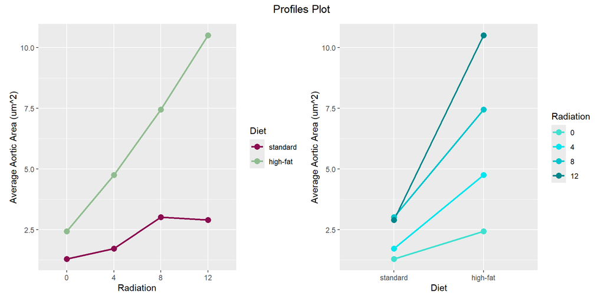

**Figure 2:** Profiles Plots. Average Aortic Area is plotted against Radiation (a) or Diet (b).The different slopes of the plotted lines is informative on the potential interaction between the two treatments.

Based on the exploratory graphical analysis a few preliminary observations can be made for the data: - The aortic area is higher for high-fat diet compared with standard diet for all radiation treatments.

- The aortic area increases with higher doses of radiation in mice with high-fat diet.
- However, there seems to be a smaller effect of radiation on mice on standard diet compared to mice on high-fat diet, suggesting that radiation alone is not relevant for lesioned aortic area, but in combination with high-fat diet.
- Profiles plot indicate a potential interaction between Radiation and Diet since the slope of profiles is different depending of the treatment combination.

## 2.2 **Descriptive statistics of Aortic Area per treatment combination**

| Diet | Radiation | n | Mean | SD | SE | Var | Min | Max |
| --- | --- | --- | --- | --- | --- | --- | --- | --- |
| standard | 0 | 10 | 1.284 | 0.728 | 0.230 | 0.530 | 0.365 | 2.42 |
| standard | 4 | 10 | 1.712 | 0.931 | 0.294 | 0.866 | 0.390 | 2.89 |
| standard | 8 | 10 | 3.010 | 0.884 | 0.280 | 0.781 | 1.220 | 4.00 |
| standard | 12 | 10 | 2.900 | 1.267 | 0.401 | 1.606 | 0.720 | 4.62 |
| high-fat | 0 | 10 | 2.429 | 1.018 | 0.322 | 1.037 | 1.210 | 4.45 |
| high-fat | 4 | 10 | 4.755 | 0.527 | 0.167 | 0.277 | 4.090 | 5.59 |
| high-fat | 8 | 10 | 7.449 | 1.059 | 0.335 | 1.121 | 5.340 | 9.29 |
| high-fat | 12 | 10 | 10.512 | 0.939 | 0.297 | 0.882 | 9.140 | 11.70 |

**Table 3:** Descriptive statistical summary for the dataset. Area’s statistics are evaluated for the different combination of treatments Diet and Radiation. n: sample size for the treatment combination, SD: standard deviation, SE: standard error, Var: Variance, Min: minimum, Max: maximum.

# 3 **Statistical Analysis**

## 3.1 **Mixed ANOVA model**

The proposed model is an Anova mixed model with two fixed effects (Diet and Radiation) and one random effect (Mouse) nested in the combination of treatments. A term for the interaction between Diet and Radiation was included based on the profiles graphs interpretation.

$$\mathbf{Y_{ijkl} = \mu + \alpha_i + \beta_j + \alpha*\beta_{ij} +
M_{k(ij)} + \epsilon_{ijkl}}$$

$$\alpha_i = \text{Effect of i-th diet, i=1,2}$$

$$\beta_j= \text{Effect of j-th radiation treatment, j= 1,2,3,4}$$

$$M_{k(ij)}= \text{Random effect of k-th n mouse nested in the
diet-radiation combination. } k=1,2,3...40$$

$$M_{k(ij)} \approx N(0,\sigma_M^2)$$

$$l= \text{histological sample. }l=1,2$$

$$\epsilon_{ijkl} = Error \approx N(0,\sigma^2)$$

## 3.2 **Mixed ANOVA Results**

|  | Sum Sq | Mean Sq | NumDF | DenDF | F value | Pr(>F) |
| --- | --- | --- | --- | --- | --- | --- |
| Radiation | 49.13595 | 16.378651 | 3 | 32 | 56.16527 | 7.548332e-13 |
| Diet | 58.88160 | 58.881605 | 1 | 32 | 201.91535 | 2.256189e-15 |
| Radiation:Diet | 19.90599 | 6.635331 | 3 | 32 | 22.75371 | 4.478761e-08 |

**Table 4:** Analisis of Variance for mixed effect model.

## 3.3 **Model Diagnostics**

The proposed model assumes aproximate normal distribution for errors and random effects. It also implies homocesdasticity of errors.

$$\epsilon_{ijkl} \approx N(0,\sigma^2)$$

$$M_{k(ij)} \approx N(0,\sigma_M^2)$$

Errors are non observable, but they can be estimated from model residuals. In the following sections evaluation of residuals and random effects will be performed to evaluate the validity of the assumptions for the proposed model.

### 3.3.1 **Testing Residual Normality**

Residuals were graphically and statistically evaluated with a Shapiro-Wilks Normality test.

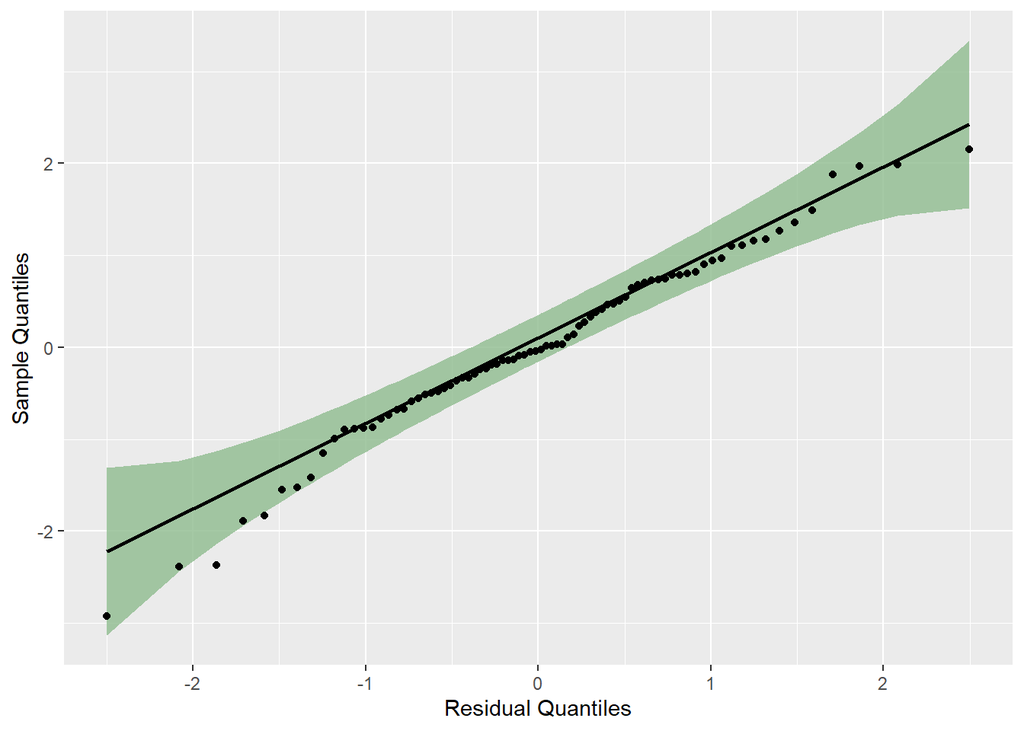

**Figure 3:** Quantile-Quantile plot of sample residual quantiles vs normal residual quantiles. line: quantile-quantile trend line for a normal distribution. band: 95% confience band for a normal distribution.

```
##
##  Shapiro-Wilk normality test
##
## data:  residuals_m1
## W = 0.98216, p-value = 0.3284
```

**Table 4:**Shapiro-Wilks normality test for Residuals.

Table 4 indicates that normality of residuals is not violated. Shapiro-Wilks test (W= 0.98216, p=0.3284)

Residual Quantiles plot in Figure 3 shows one observation outside confidence band for normal quantiles. Further analysis were performed to evaluate if this observation corresponds to an outlier.

### 3.3.2 **Testing Homocedasticity of Residuals**

Homocedasticity of Errors was evaluated on residuals graphically and with Levene’s Homogeneity of Variance Test.

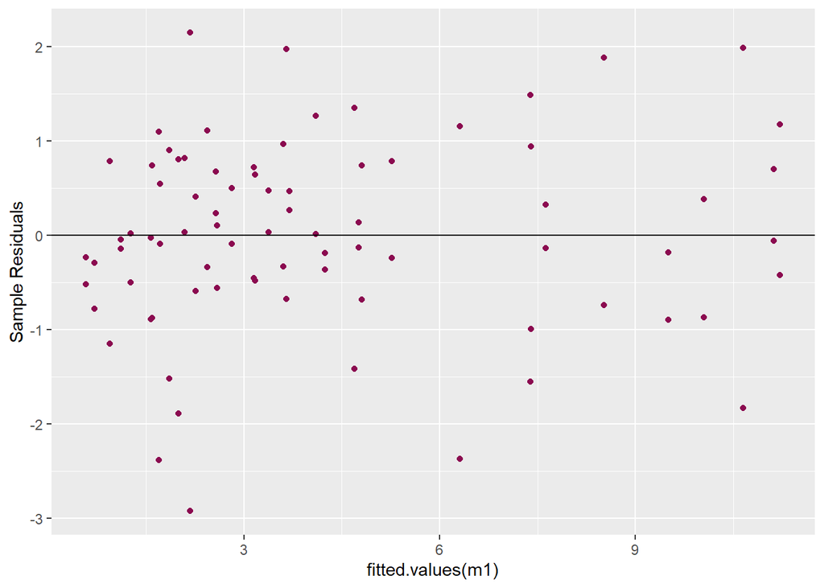

**Figure 4:** Plot of Residuals vs Fitted values (Area)

```
## Levene's Test for Homogeneity of Variance (center = mean)
##       Df F value Pr(>F)
## group  7  1.0459 0.4073
##       72
```

**Table 5:** Levene Test of Homogeneity for residual variance.

Plot for residuals vs Area fitted values does not show any tendency in the distribution of residuals Additionally, Levene’s test is non-significant (F(7,72)= 1.046, p=0.407). Results are indicative that Homogeneity of residual variance is not violated.

### 3.3.3 **Testing Normality of Random Effects**

Normality of Random Effect, Mouse, was evaluated graphically and statistically with Shapiro-Wilks Normality Test.

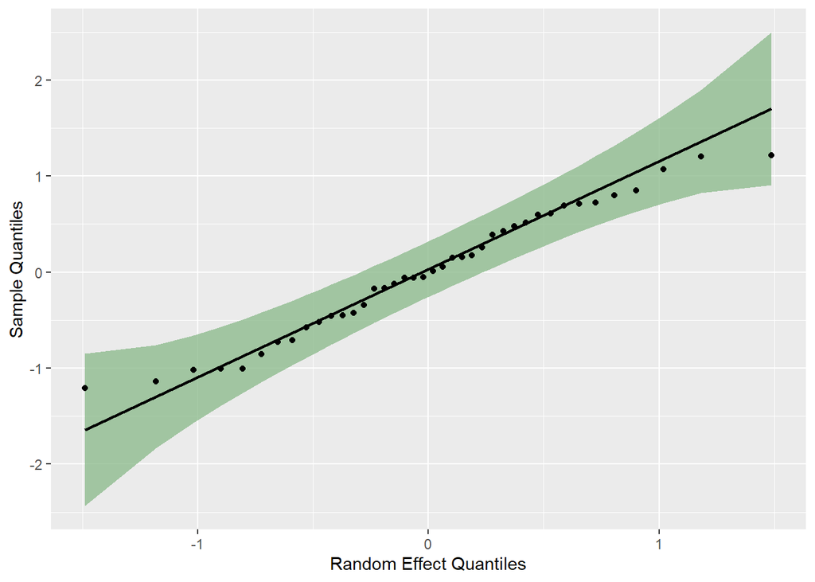

**Figure 5:** Plot of Random Effect sample quantiles vs Normal Quantiles. line: quantile-quantile normal trend line. band: 95% confidence normal quantile band.

```
##
##  Shapiro-Wilk normality test
##
## data:  ranef(m1)$Mouse$"(Intercept"
## W = 0.97201, p-value = 0.4157
```

**Table 6:** Shapiro-Wilks Test for normality of Random Effects.

In Figure 5, no sample quantiles fall outside the confidence band for normal distribution. Moreover, Shapiro-Wilks test was non significant (W=0.972, p=0.416). Both results indicate that normality of random effects was not violated.

### 3.3.4 **Analysis of potential outliers**

```
## No Studentized residuals with Bonferroni p < 0.05
## Largest |rstudent|:
##     rstudent unadjusted p-value Bonferroni p
## 75 -2.922639          0.0046894      0.37515
```

**Table 7:** t-student Outlier Test with Bonferroni p-value adjustment.

Adjusted p-value for potential outlier observation number 75 showed a non-significant p-value and a statistic absolute value below 3 (rstudent= -2.922, adjusted p= 0.375). Outlier test indicates that there are no outliers present in the dataset.

## 3.4 **Estimated parameters for the model**

Variance, Variance between mice, model mean, the fixed effects for each treatment level and treatment interactions estimated by the model, and intraclass correlation coeficient (ICC) are obtained from the following Table.

|  | Area |  |  |  |  |
| --- | --- | --- | --- | --- | --- |
| Predictors | Estimates | std. Error | CI (95%) | p | df |
| 0 Gy - Standard | 1.284 | 0.404 | 0.478 – 2.089 | **0.002** | 70.000 |
| 4 Gy | 0.428 | 0.571 | -0.711 – 1.568 | 0.456 | 70.000 |
| 8 Gy | 1.726 | 0.571 | 0.587 – 2.866 | **0.004** | 70.000 |
| 12 Gy | 1.616 | 0.571 | 0.477 – 2.756 | **0.006** | 70.000 |
| High-fat | 1.145 | 0.571 | 0.006 – 2.285 | **0.049** | 70.000 |
| 4 Gy: High-fat | 1.898 | 0.808 | 0.286 – 3.509 | **0.022** | 70.000 |
| 8 Gy: High-fat | 3.294 | 0.808 | 1.682 – 4.905 | **<0.001** | 70.000 |
| 12 Gy: High-fat | 6.467 | 0.808 | 4.855 – 8.078 | **<0.001** | 70.000 |
| Random Effects |  |  |  |  |  |
| σ<sup>2</sup> | 0.292 |  |  |  |  |
| τ<sub>00</sub> <sub>Mouse</sub> | 0.671 |  |  |  |  |
| ICC | 0.697 |  |  |  |  |
| N <sub>Mouse</sub> | 40 |  |  |  |  |
| Observations | 80 |  |  |  |  |
| Marginal R<sup>2</sup> / Conditional R<sup>2</sup> | 0.904 / 0.971 |  |  |  |  |

**Table 8:** Summary of Estimated parameters.

The main parameters extracted from the table above expressed in terms of the model can be summarized as follows:

$$\sigma^2=0.292$$

$$\begin{align}
\text{Random effects } M_{k(ij)} \text { obtained from the model
are:}
\end{align}$$

| Mouse | Mouse_Effect |
| --- | --- |
| 1 | -0.707 |
| 2 | 0.802 |
| 3 | -0.344 |
| 4 | -0.175 |
| 5 | 0.424 |
| 6 | 1.216 |
| 7 | -0.168 |
| 8 | -0.858 |
| 9 | 0.387 |
| 10 | -0.578 |

[output cut: 30 more lines]

**Table 9:** Model Random Effects.

### 3.4.1 **Intraclass Correlation Coeficient (ICC)**

```
## var.random
##  0.6969032
```

Based on Intraclass correlation coeficient, 69.7% of random variability of lesioned aortic area it is due to variability between mice.

## 3.5 **Treatment Means and Comparisons of Treatment combinations**

### 3.5.1 **Treatment Means**

| Diet | Radiation | Mean | SE | Lower (95% CI) | Upper (95% CI) |
| --- | --- | --- | --- | --- | --- |
| standard | 0 | 1.284 | 0.404 | 0.460 | 2.107 |
| high-fat | 0 | 2.429 | 0.404 | 1.606 | 3.252 |
| standard | 4 | 1.712 | 0.404 | 0.889 | 2.535 |
| high-fat | 4 | 4.755 | 0.404 | 3.932 | 5.578 |
| standard | 8 | 3.010 | 0.404 | 2.187 | 3.833 |
| high-fat | 8 | 7.449 | 0.404 | 6.626 | 8.272 |
| standard | 12 | 2.900 | 0.404 | 2.077 | 3.723 |
| high-fat | 12 | 10.512 | 0.404 | 9.689 | 11.335 |

**Table 10:** Treatment combination means. SE: Standard Error. Lower (95% CI) and Upper (95% CI): Lower and upper limit 95% confidence intervals.

### 3.5.2 **Multiple comparisons**

| Contrasts | Mean diff | Lower (95% CI) | Upper (95% CI) | p | S |
| --- | --- | --- | --- | --- | --- |
| standard 0 - (high-fat 0) | -1.145 | -2.997 | 0.706 | 0.495 | NS |
| standard 0 - standard 4 | -0.428 | -2.28 | 1.423 | 0.995 | NS |
| standard 0 - (high-fat 4) | -3.471 | -5.323 | -1.62 | 0 | S |
| standard 0 - standard 8 | -1.726 | -3.578 | 0.125 | 0.082 | NS |
| standard 0 - (high-fat 8) | -6.165 | -8.017 | -4.314 | 0 | S |
| standard 0 - standard 12 | -1.616 | -3.468 | 0.235 | 0.123 | NS |
| standard 0 - (high-fat 12) | -9.228 | -11.08 | -7.377 | 0 | S |
| (high-fat 0) - standard 4 | 0.717 | -1.134 | 2.568 | 0.908 | NS |
| (high-fat 0) - (high-fat 4) | -2.326 | -4.177 | -0.475 | 0.006 | S |
| (high-fat 0) - standard 8 | -0.581 | -2.432 | 1.27 | 0.968 | NS |

[output cut: 18 more lines]

**Table 11:** Tukey Multiple contrasts. Mean diff: mean difference between treatment combinations. Lower (95% CI), Upper (95% CI): upper and lower limit confidence interval (95% confidence). p: p-value. S: significance, NS: non-significant, S: significant based on threshold of 0.05.

### 3.5.3 **Simple Main Effects**

Simple main effects were estimated in the table below per Radiation treatment intensity.

1. |  | contrast | Radiation | estimate | SE | df | t.ratio | p | S |
   | --- | --- | --- | --- | --- | --- | --- | --- | --- |
   | 1 | standard - (high-fat) | 0 | -1.145 | 0.571 | 32 | -2.005 | 0.054 | NS |
   | 2 | standard - (high-fat) | 4 | -3.043 | 0.571 | 32 | -5.325 | 0.000 | S |
   | 3 | standard - (high-fat) | 8 | -4.439 | 0.571 | 32 | -7.768 | 0.000 | S |
   | 4 | standard - (high-fat) | 12 | -7.612 | 0.571 | 32 | -13.321 | 0.000 | S |

2. |  | contrast | Diet | estimate | SE | df | t.ratio | p | S |
   | --- | --- | --- | --- | --- | --- | --- | --- | --- |
   | 1 | 0 - 4 | standard | -0.428 | 0.571 | 32 | -0.750 | 0.876 | NS |
   | 2 | 0 - 8 | standard | -1.726 | 0.571 | 32 | -3.021 | 0.024 | S |
   | 3 | 0 - 12 | standard | -1.616 | 0.571 | 32 | -2.829 | 0.038 | S |
   | 4 | 4 - 8 | standard | -1.298 | 0.571 | 32 | -2.272 | 0.126 | NS |
   | 5 | 4 - 12 | standard | -1.188 | 0.571 | 32 | -2.079 | 0.182 | NS |
   | 6 | 8 - 12 | standard | 0.110 | 0.571 | 32 | 0.193 | 0.997 | NS |
   | 7 | 0 - 4 | high-fat | -2.326 | 0.571 | 32 | -4.071 | 0.002 | S |
   | 8 | 0 - 8 | high-fat | -5.020 | 0.571 | 32 | -8.785 | 0.000 | S |
   | 9 | 0 - 12 | high-fat | -8.083 | 0.571 | 32 | -14.145 | 0.000 | S |
   | 10 | 4 - 8 | high-fat | -2.694 | 0.571 | 32 | -4.715 | 0.000 | S |

   [output cut: 2 more lines]

**Table 12:** Simple effects on Radiation (a) and on Diet (b). Contrast: Treatment compared per level of radiation (a) or diet (b). Estimate: mean difference between treatment combinations. SE: Standard Error. df: degrees of freedom. t.ratio: statistic. p.value: p-value.

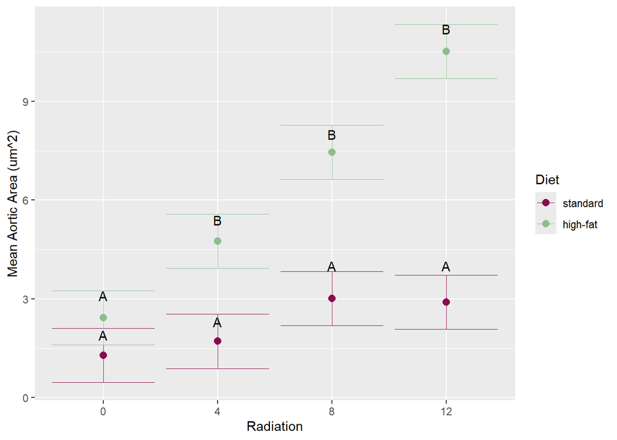

**Figure 6:** Mean comparison between treatment combinations. A vs B: significant difference between treatment combinations.

Simple main effects tests indicate that the Area was significantly higher between standard vs high-fat diet for all Radiation (4, 8 and 12 Gy) intensities (p<0.001, p<0.001, p<0.001). In absence of Radiation (0 Gy) there is no significant difference between standard and high-fat diet on aortic area lesion (p = 0.0535).

Interestingly, for high-fat diet, each increase in radiation intensity resulted in a significantly higher area of lesion compared to the immediate previous radiation intensity (0 Gy vs 4 Gy: p=0.0016 .4 Gy vs 8 Gy: p=0.0003 . 8Gy vs 12 Gy: p<0.001.). In contrast, for standard diet, there was only a significant increase of damaged area between 0 Gy and 8 Gy, and 0 Gy and 12 Gy Radiation levels (p=0.024, p=0.038).

# 4 **Conclusion**

The analysis performed indicates that high-fat or standard diet is not indicative of aortic damage. However, the presence of high-fat diet significantly increases the damage induced by radiation. In standard diet individuals, radiation has damaging effect on the aorta but only on higher intensities of radiation and in lower magnitude compared with high-fat diet mice. The results suggest that the fat content on diet could be protective (standard fat diet) or damaging (high-fat diet) of vascular endothelium in patients treated with ionizing radiation.